# Capacitación Python

Escribir programas (o programar) es una actividad muy creativa y gratificante. Puedes escribir programas por muchas razones, que pueden ir desde mantenerte activo resolviendo un problema de análisis de datos complejo hasta hacerlo por pura diversión ayudando a otros a resolver un enigma.

En nuestra vida diaria estamos rodeados de computadoras, desde equipos portátiles (laptops) hasta teléfonos móviles (celulares). Podemos pensar en esas computadoras como nuestros “asistentes personales”, que pueden ocuparse de muchas tareas por nosotros. El hardware en los equipos que usamos cada día está diseñado esencialmente para hacernos la misma pregunta de forma constante, “¿Qué quieres que haga ahora?”

Nuestros equipos son rápidos y tienen grandes cantidades de memoria. Podrían resultarnos muy útiles si tan solo supiéramos qué idioma utilizar para explicarle a la computadora qué es lo que queremos que “haga ahora”. Si conociéramos ese idioma, podríamos pedirle al aparato que realizase en nuestro lugar, por ejemplo, tareas repetitivas. Precisamente el tipo de cosas que las computadoras saben hacer mejor suelen ser el tipo de cosas que las personas encontramos pesadas y aburridas.

Por ejemplo, mira los primeros tres párrafos de cualquier capitulo de un libro y digame cuál es la palabra que más se repite, y cuántas veces se ha utilizado. Aunque seas capaz de leer y comprender las palabras en pocos segundos, contarlas te resultará casi imposible, porque la mente humana no fue diseñada para resolver ese tipo de problemas. Para una computadora es justo al revés, leer y comprender texto de un trozo de papel le sería difícil, pero contar las palabras y decirte cuántas veces se ha repetido la más utilizada le resulta muy sencillo.

# **Estructuras de control**

El objetivo de este Notebook es presentar algunos conceptos sobre las estructuras de control de flujo en Python. Se desarrollará los siguientes temas:

- Flujo de datos (entrada y salida)
- Tipos de datos
- Manipulación de expresiones aritméticas
- Condicionales
- Ciclos

**Es importante mencionar que este Notebook no presenta una revisión exhaustiva sobre los temas mencionados. Para más información se recomienda consultar la documentación oficial.**

$$h^2 = a^2 +b^2 \text{ si } a=\frac{x}{y}$$

### ¿Qué es un programa?

Podemos definir un programa, en su forma más básica, como una secuencia de declaraciones o sentencias que han sido diseñadas para hacer algo. Incluso nuestro sencillo script “hola.py” es un programa. Es un programa de una sola línea y no resulta particularmente útil, pero si nos ajustamos estrictamente a la definición, se trata de un programa en Python. Tal vez resulte más fácil comprender qué es un programa pensando en un problema que pudiera ser resuelto a través de un programa, y luego estudiando cómo sería el programa que solucionaría ese problema. Supongamos que estás haciendo una investigación de computación o informática social en mensajes de Facebook, y te interesa conocer cual es la palabra más utilizada en un conjunto de mensajes. Podrías imprimir el flujo de mensajes de Facebook y revisar con atención el texto, buscando la palabra más común, pero sería un proceso largo y muy propenso a errores. Sería más inteligente escribir un programa en Python para encargarse de la tarea con rapidez y precisión, y así poder emplear el fin de semana en hacer otras cosas más divertidas.

## **Flujo de datos (entrada y salida)**

Mi primer programa en Python.

```python
print("Hola Mundo")
```

```
Hola Mundo
```

```python
mundo = "Mundo"
print('Hola', mundo)
```

```
Hola Mundo
```

Recibir datos del usuario (función `input()`)

```python
numero_años = 15
#numero años =15
```

```python
type(numero_años)
```

```
int
```

```python
entrada = input("Ingrese su nombre: ")
print("Hola,", entrada, "esto es otra cadena", 12345)
print(f"Hola, {entrada}, tienes {numero_años} años")
print("Hola, {}, tienes {} años".format(entrada, numero_años))
```

```
Ingrese su nombre: Sergio
Hola, Sergio esto es otra cadena 12345
Hola, Sergio, tienes 15 años
Hola, Sergio, tienes 15 años
```

```python
# prompt: genera un script donde pida un nombre y la fecha de nacimiento y realice un saludo mencionando el nombre y la edad

# Get the user's name.
name = input("What is your name? ")

# Get the user's birth year.
birth_year = int(input("What year were you born? "))

# Calculate the user's age.
age = 2024 - birth_year

# Print a greeting.
print(f"Hello, {name}! You are {age} years old.")
```

```
What is your name? David
What year were you born? 1998
Hello, David! You are 26 years old.
```

### **Comentarios**

Python nos permite agregar comentarios para documentar nuestro código. Los comentarios no serán tenidos en cuenta por el interprete. Podemos tener comentarios de una única línea utilizando el símbolo `#`

```python
b = 'aa'   # Esto es un comentarios de una línea
print(b * 10)
# Este es otro comentario en Python.
# Es posible tener tantos comentarios de una única línea como se requiera
```

```
aaaaaaaaaaaaaaaaaaaa
```

También es posible crear comentarios de múltiples líneas utilizando tres comillas simples `'''` o tres comillas dobles `"""`

```python
print('''Este es un comentario multilínea.
Podemos 'a' escribir tantas líneas queramos ''')
print("comillas doles citando una comilla sencilla 'a'")
print('comillas sencillas citando una comilla doble "a"')
#print('en comillas sencillas no puedo citar una comilla sencilla 'a'')
"""Este "b" es un comentario multilínea.
Podemos escribir tantas líneas queramos """

b = 3
b
#print(b * 5)

#'''También podemos hacer "w", 'B'comentarios multilíneas con comillas simples.'''
#"""También podemos hacer comentarios multilíneas con comillas simples."""
#'''También podemos hacer "w", 'B' comentarios multilíneas con comillas simples.'''
```

```
Este es un comentario multilínea.
Podemos 'a' escribir tantas líneas queramos
comillas doles citando una comilla sencilla 'a'
comillas sencillas citando una comilla doble "a"
```

```
3
```

Podemos combinar las comillas simples y las dobles según lo necesitemos:

```python
'''Este es un comentario en el cual "existen" comillas dobles'''
"""Este es un comentario en el cual "existen" comillas dobles"""
```

```
'Este es un comentario en el cual "existen" comillas dobles'
```

```python
def mi_funcion():
    return ':)'
```

```python
mi_funcion()
```

```
':)'
```

### **`CamelCase` y `snake_case`**

Python combina los estilos `snake_case` y `CamelCase` en su sintaxis:

- **snake_case:** letras_minusculas_separadas_por_underscore `my_variable`, `my_function`, `my_module`
- **CameCase:** Primera letra de cada palabra Mayuscúla `ClassName`, `methodName`, `myVariable`.
- **Constantes**: TODO_EN_MAYUSCULA `PI = 3.1415`, `ALL_UPPERCASE = True`

Para la declaración de variables, funciones, clases, etc. es una buena práctica seguir las recomendaciones [PEP8](https://realpython.com/python-pep8/#naming-styles). En general, usaremos CamelCase para los nombres de las clases y snake_case para todo lo demás

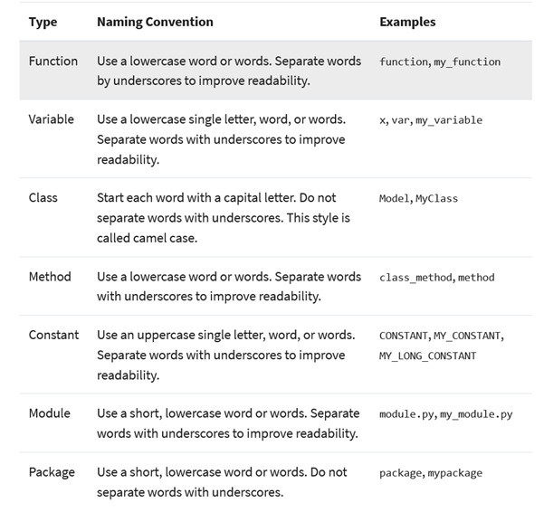

## **Tipos de datos**

Python nos permite declarar variables con los siguientes tipos de datos:

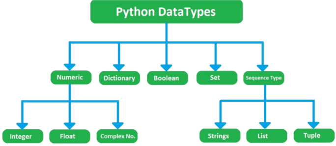

Por el momento solo nos concentratermos en los tipos de datos numéricos (`integer` y `float`) booleanos `(boolean)` y cadenas de caracteres (`string`)

```python
var_dic = {'key_0': 1, 'Edad': 28, 'Nombre': 'Juan', 'Peso y talla': [50, 175], 'dicc': {'key_1': 0}}
```

```python
var_dic
```

```
{'key_0': 1,
 'Edad': 28,
 'Nombre': 'Juan',
 'Peso y talla': [50, 175],
 'dicc': {'key_1': 0}}
```

```python
print(type(True))
print(type(False))
```

```
<class 'bool'>
<class 'bool'>
```

```python
set([1,2,2,1,3,3])
```

```
{1, 2, 3}
```

```python
{1,2,2,1,3,3}
```

```
{1, 2, 3}
```

```python
[1,2,2,1,3,3]
```

```
[1, 2, 2, 1, 3, 3]
```

```python
(1,2,2,1,3,3)
```

```
(1, 2, 2, 1, 3, 3)
```

```python
print(type("Una cadena"))
print(type(2.33))
print(type(111))
print(type(True))
print(type({"key_1":0}))
print(type([1,2,3,4]))
print(type({1,2,3,4}))
print(type((1,2)))
```

```
<class 'str'>
<class 'float'>
<class 'int'>
<class 'bool'>
<class 'dict'>
<class 'list'>
<class 'set'>
<class 'tuple'>
```

### Variables

Una de las características más potentes de un lenguaje de programación es la capacidad de manipular variables. Una variable es un nombre que se refiere a un valor.

```python
mensaje = "Estamos aprendiendo Python"
print(mensaje, type(mensaje))
mensaje = 2021
print(mensaje, type(mensaje))
mensaje = 3.1415
print(mensaje, type(mensaje))
```

```
Estamos aprendiendo Python <class 'str'>
2021 <class 'int'>
3.1415 <class 'float'>
```

```python
print(mensaje, type(mensaje))
#print(n, type(n))
#print(pi, type(pi))
```

```
3.1415 <class 'float'>
```

## Nombres de variables y palabras claves

Los programadores generalmente eligen nombres para sus variables que tengan sentido y documentan para qué se usa esa variable. Los nombres de las variables pueden ser arbitrariamente largos. Pueden contener tanto letras como números, pero no pueden comenzar con un número. Se pueden usar letras mayúsculas, pero es buena idea comenzar los nombres de las variables con una letras minúscula.

```python
79numero = 25
```

```
  File "<ipython-input-37-7fa92066e6d3>", line 1
    79numero = 25
     ^
SyntaxError: invalid decimal literal
```

```python
var25 = 25
```

```python
numero@ = 25
```

[output not shown]

```python
class = 25
```

```
  File "<ipython-input-42-e7cdbfb88d3e>", line 1
    class = 25
          ^
SyntaxError: invalid syntax
```

## Palabras resevadas

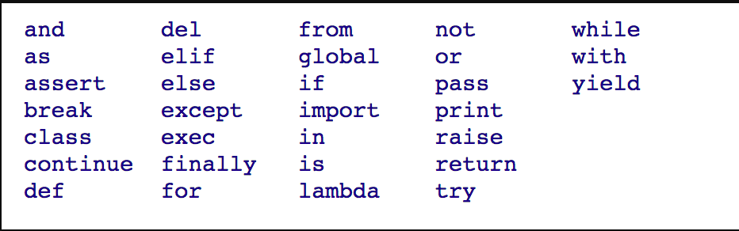

Fuente: https://s3.amazonaws.com/media-p.slid.es/uploads/732583/images/5358524/Screen_Shot_2018-10-13_at_01.22.24.png

```python
a=3
b=a
c=b+1
print(a,b,c)
print(type(a),type(b),type(c))
```

```
3 3 4
<class 'int'> <class 'int'> <class 'int'>
```

Un ejemplo simple utilizando la función `input()`

```python
a = float(input("Ingrese el primer número: "))
b = int(input("Ingrese el segundo número: "))

print(f"El resutlado de la suma : {a + b}")
```

```
Ingrese el primer número: 5.6
Ingrese el segundo número: dos
```

```
---------------------------------------------------------------------------
ValueError                                Traceback (most recent call last)
<ipython-input-45-02a985c45a21> in <cell line: 2>()
      1 a = float(input("Ingrese el primer número: "))
----> 2 b = int(input("Ingrese el segundo número: "))
      3
      4 print(f"El resutlado de la suma : {a + b}")

ValueError: invalid literal for int() with base 10: 'dos'
```

### **Tipado**

Python en es lenguaje de programación con:

- **Tipado dinámico**: una variable puede cambiar su tipo en tiempo de ejecución.

```python
a = 5
print(a, type(a))
a = "Hola mundo"
print(a, type(a))
```

```
5 <class 'int'>
Hola mundo <class 'str'>
```

- **Fuertemente tipado**: no permite realizar operaciones entre tipos de datos incompatibles.

```python
a = ["5", "4"]
b = 3 #["7", 4]
print(a * b)  # ¡Error!
```

```
['5', '4', '5', '4', '5', '4']
```

```python
a = 2
b = "7a"
print(a * b)
```

```
7a7a
```

Para realizar operaciones entre distintos datos se debe realizar la conversión de manera explicita

```python
print(a + int(b))
```

```
---------------------------------------------------------------------------
ValueError                                Traceback (most recent call last)
<ipython-input-59-70d6ec22298e> in <cell line: 1>()
----> 1 print(a + int(b))

ValueError: invalid literal for int() with base 10: '7a'
```

### **Anotaciones**

A pesar de ser un lenguaje de tipado dinámico, Python soporta (de forma opcional) un sistema de tipos estáticos usando *anotaciones*. Para esto usamos la siguiente sintaxis `<variale> : <tipo de dato> = <valor>`

```python
a : int = 10
b : float = 3.14
c : bool = False
d : str = 'Hola Mundo'
```

Debido a que el tipado estático es opcional el interprete no generará un error si una variable cambia su tipo en tiempo de ejecución

```python
a: int = 5
print(a, type(a))
a = "Hola mundo" # Esto no arroja ningún error durante la ejecución.
print(a, type(a))
```

```
5 <class 'int'>
Hola mundo <class 'str'>
```

También podemos crear variables sin inicializar

```python
mensaje : str
```

```python
mensaje : str
print(mensaje)
```

```
3.1415
```

Podemos generar anotaciones para colecciones, funciones y clases. Esto se revisará durante las próximas sesiones.

### **Conversión entre tipos de datos**

Podemos realizar conversiones entre diferentes tipos de datos utilizando las funciones incorporadas disponibles en Python

```python
entrada = input("Ingrese un número: ")
print(entrada, type(entrada))
entrada = float(entrada)
print(entrada, type(entrada))
entrada = int(entrada)
print(entrada, type(entrada))
entrada = bool(entrada)
print(entrada, type(entrada))
```

```
Ingrese un número: 25
25 <class 'str'>
25.0 <class 'float'>
25 <class 'int'>
True <class 'bool'>
```

```python
bool(0)
```

```
False
```

```python
print(bool(0), bool(5), bool(-1.2), bool(0.0), bool(0.0000000000000001))
```

```
False True True False True
```

```python
print(bool('0'), bool('5'), bool('-1.2'), bool('sdasd'), bool(''))
```

```
True True True True False
```

También podemos ejecutar funciones de manera anidada:

```python
a = int(input("Ingrese el primer número: "))
b = float(input("Ingrese el segundo número: "))

print(f"El resutlado de la suma: {a + b}")
```

```
Ingrese el primer número: 5
Ingrese el segundo número: 2.5
El resutlado de la suma: 7.5
```

## **Manipulación de Expresiones**

Podemos generar expresiones ariméticas y expresiones lógicas.

### **Expresiones aritméticas**

Python cuenta con la siguente sintaxis para realizar operaciones aritméticas

```python
a : int = 2
b : int = 10

suma = a + b
print(suma)
resta = a - b
print(resta)
producto = a * b
print(producto)
division = a / b
print(division)
division_entera = a // b
print(division_entera)
potencia = a ** b
print(potencia)
radicacion = a ** (1 / b)
print(radicacion)
modulo = b % 2
print(modulo)
```

```
12
-8
20
0.2
0
1024
1.0717734625362931
0
```

Jearquía de las operaciones ariméticas

- Signos de agrupación
- Potencias y raices
- Multiplicación y división
- sumas y restas

```python
a=6/2*3-1
a
```

```
8.0
```

```python
a = 2*3/2+1
'asdd'
a
```

```
4.0
```

### **Operadores de asignación**

Podemos realizar los siguientes operadores para realizar asignaciones a una variable

```python
x = 125 	# x = 5
x += 3 	# x = x + 3
x -= 3 	# x = x - 3
x *= 3 	# x = x * 3
x /= 3 	# x = x / 3
x %= 3 	# x = x % 3
x //= 3 # x = x // 3
x **= 3 # x = x ** 3
x
```

```
0.0
```

$$\frac{(4+1)^2}{3}$$

```python
x=((4+1)**2)/3
x
```

```
8.333333333333334
```

### **Expresiones booleanas**

Podemos definir una expresión lógica como una proposición que tendrá un valor de verdad: cierto o falso. Para construir proposiciones podemos utilizar los operadores $\le, ≥, =, \lt, \gt, \neq$.

```python
a=5
print(a)
print(a < 3)
print(a <= 3)
print(a >= 3)
print(a > 3)
print(a == 3)
print(a != 3)
```

```
5
False
False
True
True
False
True
```

También podemos generar condiciones más complejas utilizando las operadores lógicas `and`,`or` y `not`

```python
c = 2 == 2.0
c
```

```
True
```

```python
a = 0 > 3 # False
b = 5 >= 2 # True
c = 2 == 2.0 # True
# operaciones logicas: and, or, not
print(a and b and c)
print(a or b or c)
print(not(a))
print(not(b))
print(not(a and b and c))
```

```
False
True
True
False
True
```

Todos los tipos de datos tiene un equivalente en booleano. Este idea está relacionada con los valores que python considera `Falsy`

```python
falsy_values = (0, False, None, '', [], {})

print('0 -> boolean:', bool(0))
print('None -> boolean:', bool(None))
print("'' -> boolean:", bool(''))
print('[] -> boolean:', bool([]))
print('{} -> boolean:', bool([]))
```

```
0 -> boolean: False
None -> boolean: False
'' -> boolean: False
[] -> boolean: False
{} -> boolean: False
```

```python
def constate_50():
    return 50
```

```python
global CTE_50
```

```python
CTE_50 = 50
```

```python
CTE_50 = 40
```

```python
constate_50 = 40
```

### **Ejercicio 1: Indice de masa muscular.**

Construir un algoritmo que permita calcular el IMC teniendo en cuenta que:

$IMC=\frac{Peso(Kg)}{Altura^2(m)}$

¿Qué variables solicitaría del usuario?

- Si un usuario le comenta que su IMC es de $22.3$ y su estatura es de $1.64 m$, ¿Cómo estimaría el peso del usuario?
- Si un usuario le comenta que su IMC es de $25$ y su peso es de $78 kg$ , ¿Cómo estimaría la estatura del usuario?

```python
# Solución propuesta

P = float(input("Ingrese el peso: "))
A = float(input("Ingrese la altura "))
IMC = (P/A**2)
print(f"El indice de masa corporal es {IMC}")
```

```
Ingrese el peso: 60
Ingrese la altura 1.65
El indice de masa corporal es 22.03856749311295
```

```python
peso = float(input("Ingrese peso: "))
talla = float(input("Ingrese talla: "))

print(f"IMC: {peso / talla**2}")
```

```
Ingrese peso: 60
Ingrese talla: 165
IMC: 0.0022038567493112946
```

```python
peso = int (input("ingrese su peso en KG "))
altura =float (input("ingrese la altura en CM "))
altura = altura/100
#print (altura)
imc = peso / (altura**2)
print(round(imc,2))
```

```
ingrese su peso en KG 60
ingrese la altura en CM 165
22.04
```

```python
a=3
b=1.4
c='caracter'
print(type(a),type(b),type(c))
```

```
<class 'int'> <class 'float'> <class 'str'>
```

### **Ejercicio 2: Cantidad de centros de atención**

Suponga que una eps tiene centros de salud de 3 tipos:

- Tipo A: Atiende una pobración de 6530 personas
- Tipo B: Atiende una población de 8324 personas
- Tipo C: Atiende una población de 11450 personas

Escriba un programa que le pregunte al usuario dos combinaciones de tipos de eps, compare entre esas dos combinaciones y establezca cuál de estas es la que mayor cantidad de usuarios impacta.

Ej:

**Entrada:**

Combinación 1: 1 centro de tipo C.

Combinación 2: 2 centros de tipo A.

**salida:**

La combinación 2 impacta más usuarios.

```python
def comb():
    """
    input : No requiere variables de ingreso
    output: 3 valores que son solicitados al usaurio
    procesamiento: input de valores y formateo en números enteros de estos
    """
    a = input('Ingrese la cantidad de centros tipo A: ')
    b = input('Ingrese la cantidad de centros tipo B: ')
    c = input('Ingrese la cantidad de centros tipo C: ')
    return int(a), int(b), int(c)

def fuc_comparacion():
    print('Ingrese los valores de la eps 1')
    a1, b1, c1 = comb()
    print('Ingrese los valores de la eps 2')
    a2, b2, c2 = comb()
    imp1 = 6530*a1 + 8324*b1 +11450*c1
    imp2 = 6530*a2 + 8324*b2 +11450*c2
    if imp1 > imp2:
        return print('La combinación 1 es más efectiva')
    else:
        return print('La combinación 2 es más efectiva')
```

```python
help(comb)
```

```
Help on function comb in module __main__:

comb()
    input : No requiere variables de ingreso
    output: 3 valores que son solicitados al usaurio
    procesamiento: input de valores y formateo en números enteros de estos
```

```python
fuc_comparacion()
```

```
Ingrese los valores de la eps 1
Ingrese la cantidad de centros tipo A: 0
Ingrese la cantidad de centros tipo B: 0
Ingrese la cantidad de centros tipo C: 1
Ingrese los valores de la eps 2
Ingrese la cantidad de centros tipo A: 2
Ingrese la cantidad de centros tipo B: 0
Ingrese la cantidad de centros tipo C: 0
La combinación 2 es más efectiva
```

```python
# Solución propuesta

''' Dos centros de salud de tipo A y una de tipo B. Una segunda combinación como una de tipo B y una de tipo C'''

combinacion_1=2*6530+1*8324
combinación_2=1*8324+1*11450

print(combinacion_1, combinación_2)
```

```
21384 19774
```

```python
print ("Ingrese dos combinaciones de EPS")
a = input("Ingrese A , B, C segun desee el tipo de centro de la primera combinación")
a.upper()
b = input("Ingrese la cantidad de la primera combinación")
c = input("Ingrese A , B, C segun desee el tipo de centro de la segunda combinación")
d = input("Ingrese la cantidad de la segunda combinación")
if a=='A' : a=6530
if a=='B' : a=8324
if a=='C' : a=11450
if c=='A' : c=6530
if c=='B' : c=8324
if c=='C' : c=11450
Combinación_1= a * b
Combinación_2= c * d
if Combinación_1 > Combinación_2 : print("La combinación 1 impacta mas usuarios")
else : print("La combinación 2 impacta mas usuarios")
```

```
Ingrese dos combinaciones de EPS
Ingrese A , B, C segun desee el tipo de centro de la primera combinaciónA
Ingrese la cantidad de la primera combinación3
Ingrese A , B, C segun desee el tipo de centro de la segunda combinaciónB
Ingrese la cantidad de la segunda combinación2
La combinación 1 impacta mas usuarios
```

```python
print('Ingresar la combinación 1')
a=int(input('Ingresa la cantidad de sedes de tipo A: '))
b=int(input('Ingresa la cantidad de sedes de tipo B: '))
c=int(input('Ingresa la cantidad de sedes de tipo C: '))
print('Ingresar la combinación 2')
a2=int(input('Ingresa la cantidad de sedes de tipo A: '))
b2=int(input('Ingresa la cantidad de sedes de tipo B: '))
c2=int(input('Ingresa la cantidad de sedes de tipo C: '))

combinacion_1=a*6530+b*8324+c*11450
combinación_2=a2*6530+b2*8324+c2*11450

if Combinación_1 > Combinación_2 : print("La combinación 1 impacta mas usuarios")
else : print("La combinación 2 impacta mas usuarios")
```

```
Ingresar la combinación 1
Ingresa la cantidad de sedes de tipo A: 2
Ingresa la cantidad de sedes de tipo B: 1
Ingresa la cantidad de sedes de tipo C: 0
Ingresar la combinación 2
Ingresa la cantidad de sedes de tipo A: 0
Ingresa la cantidad de sedes de tipo B: 1
Ingresa la cantidad de sedes de tipo C: 1
La combinación 1 impacta mas usuarios
```

### **Ejercicio 3: Costos de envío.**

Una persona compró 3 productos en diferentes países. Los valores de envío en cada país varían de la siguiente forma: el primero tiene un costo del 15% sobre el valor original del producto. El segundo tiene un costo del 18% sobre el valor original del producto. El tercero tiene un costo del 12% sobre el valor original del producto. Se necesita construir un programa que solicite al usuario el valor original de cada producto e imprima:

- El valor total de los tres productos incluyendo los costos de envío (se debe sumar el valor de todos los productos con sus incrementos).
- El promedio de los tres productos antes y después de realizar los incrementos

```python
# solución propuesta
```

### **Ejercicio 4: Estado.**

Teniendo en cuenta los siguientes valores considerados como normales. Escriba un programa que solicite cada dato a un paciente partícular y muestre si el paciente esta en rangos normales o no.

[output not shown]

```python
# solución propuesta
print('Ingrese los siguientes valores asociados a su estado de salud')
imc=float(input('Ingrese su IMC: '))
fc=float(input('Ingrese su frecuencia cardiaca: '))
p=float(input('Ingrese su presión diastólica: '))
o=float(input('Ingrese su saturación de oxigeno: '))

if 21.1<imc<24.9:
  print(f'Su índice de masa corporal es {imc} y se encuentra en rangos normales')
else:
  print(f'Su índice de masa corporal es {imc} y no se encuentra en rangos normales')

if fc<70:
  print(f'Su frecuencia cardíaca es {fc} y es muy buena')
else:
  print(f'Su frecuencia cardíaca es {fc}, puede estar en rangos normales o no')

if 80<p<100:
  print(f'Su presión distólica es {p} y se encuentra en rangos normales')
else:
  print(f'Su presión distólica es {p}, no se encuentra en rangos normales')

if o>95:
  print(f'Su saturación de oxigeno es {o} y se encuentra en rangos normales')
else:
  print(f'Su saturación de oxigeno es {o}, no se encuentra en rangos normales')
```

```
Ingrese los siguientes valores asociados a su estado de salud
Ingrese su IMC: 20.5
Ingrese su frecuencia cardiaca: 70
Ingrese su presión diastólica: 85
Ingrese su saturación de oxigeno: 98
Su índice de masa corporal es 20.5 y no se encuentra en rangos normales
Su frecuencia cardíaca es 70.0, puede estar en rangos normales o no
Su presión distólica es 85.0 y se encuentra en rangos normales
Su saturación de oxigeno es 98.0 y se encuentra en rangos normales
```

### **Ejercicio 5: Pacientes.**

Tres médicos de la misma especialidad atienden cada uno un número especifico de pacientes. Para facilitar la asignación del siguiente control, se tiene en cuenta un criterio partícular, se toma la cantidad total de pacientes atendidos y se dividen en números iguales, los cuales se reparten entre los diferentes médicos antes mencionados. Los que no quedan en ninguno de estos grupos, se asignaran a una lista de prorizados.

Escriba un programa que permita ingresar el número de pacientes atendidos por cada médico y devuelva la cantidad de pacientes en la lista de priorizados.

**Ej:** Si en conjunto atienten 91 pacientes, para el siguiente control, de estos cada uno atenderá 30 y 1 estará en lista de priorizados.

```python
# solución propuesta
a=int(input('Ingrese la cantidad de pacientes atendidos por el médico 1: '))
b=int(input('Ingrese la cantidad de pacientes atendidos por el médico 2: '))
c=int(input('Ingrese la cantidad de pacientes atendidos por el médico 3: '))

y=(a+b+c)%3
x=(a+b+c)//3

print(f'Cada médico atenderá {x} pacientes y {y} estarán en lista de priorizados')
```

```
Ingrese la cantidad de pacientes atendidos por el médico 1: 20
Ingrese la cantidad de pacientes atendidos por el médico 2: 22
Ingrese la cantidad de pacientes atendidos por el médico 3: 23
Cada médico atenderá 21 pacientes y 2 estarán en lista de priorizados
```